# Bayesian Causal Forest for HTE — stochtree implementation

## 7. ATE and ATT

Treatment effects are on the **latent probit scale**. To convert to an interpretable absolute risk difference, we compute the counterfactual predicted probabilities:

$$\text{Risk difference}_i = \Phi(\mu_i + \tau_i) - \Phi(\mu_i)$$

This is the marginal effect of treatment for individual $i$, averaging over the posterior. Note this is person-specific because the probit link is nonlinear — a given $\tau$ on the latent scale translates to different risk differences depending on where $\mu_i$ sits on the probit curve.

```python
rd_draws = norm.cdf(mu_draws + tau_draws) - norm.cdf(mu_draws)  # (N, num_mcmc)

ate_rd_trace = rd_draws.mean(axis=0)         # ATE per draw on prob scale
att_rd_trace = rd_draws[treated_idx].mean(axis=0)

ate_rd_mean = ate_rd_trace.mean()
att_rd_mean = att_rd_trace.mean()

# FIX: az.hdi on 1-D arrays
ate_rd_hdi     = az.hdi(ate_rd_trace, hdi_prob=0.95)
att_rd_hdi     = az.hdi(att_rd_trace, hdi_prob=0.95)
ate_latent_hdi = az.hdi(ate_trace,    hdi_prob=0.95)
att_latent_hdi = az.hdi(att_trace,    hdi_prob=0.95)

print("\n" + "=" * 60)
print("ATE (latent probit scale)")
print(f"  Mean: {ate_trace.mean():.4f}   95% HDI: [{ate_latent_hdi[0]:.4f}, {ate_latent_hdi[1]:.4f}]")
print()
print("ATT (latent probit scale)")
print(f"  Mean: {att_trace.mean():.4f}   95% HDI: [{att_latent_hdi[0]:.4f}, {att_latent_hdi[1]:.4f}]")
print()
print("ATE (absolute risk difference)")
print(f"  Mean: {ate_rd_mean:.4f}   95% HDI: [{ate_rd_hdi[0]:.4f}, {ate_rd_hdi[1]:.4f}]")
print()
print("ATT (absolute risk difference)")
print(f"  Mean: {att_rd_mean:.4f}   95% HDI: [{att_rd_hdi[0]:.4f}, {att_rd_hdi[1]:.4f}]")
print("=" * 60)
```

```
============================================================
ATE (latent probit scale)
  Mean: -0.0529   95% HDI: [-0.1448, 0.0344]

ATT (latent probit scale)
  Mean: -0.0521   95% HDI: [-0.1390, 0.0438]

ATE (absolute risk difference)
  Mean: -0.0045   95% HDI: [-0.0129, 0.0044]

ATT (absolute risk difference)
  Mean: -0.0045   95% HDI: [-0.0132, 0.0045]
============================================================
```

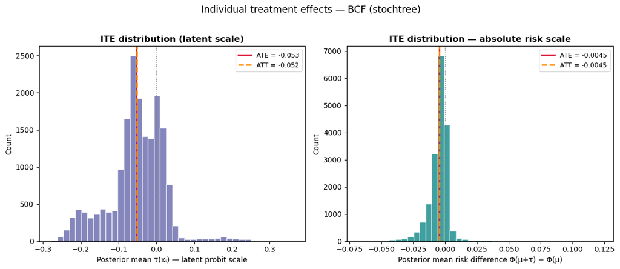

```python
ird_mean  = rd_draws.mean(axis=1)   # posterior mean risk difference per unit
tau_lo95  = np.percentile(tau_draws, 2.5,  axis=1)
tau_hi95  = np.percentile(tau_draws, 97.5, axis=1)

fig, axes = plt.subplots(1, 2, figsize=(12, 5))

ax = axes[0]
ax.hist(tau_mean, bins=40, color="#5B5EA6", alpha=0.75, edgecolor="white")
ax.axvline(tau_mean.mean(), color="crimson", lw=2, label=f"ATE = {tau_mean.mean():.3f}")
ax.axvline(tau_mean[treated_idx].mean(), color="darkorange", lw=2, linestyle="--",
           label=f"ATT = {tau_mean[treated_idx].mean():.3f}")
ax.axvline(0, color="gray", lw=1, linestyle=":")
ax.set_xlabel("Posterior mean τ(xᵢ) — latent probit scale")
ax.set_ylabel("Count")
ax.set_title("ITE distribution (latent scale)", fontweight="bold")
ax.legend(fontsize=9)

ax = axes[1]
ax.hist(ird_mean, bins=40, color="teal", alpha=0.75, edgecolor="white")
ax.axvline(ird_mean.mean(), color="crimson", lw=2, label=f"ATE = {ird_mean.mean():.4f}")
ax.axvline(ird_mean[treated_idx].mean(), color="darkorange", lw=2, linestyle="--",
           label=f"ATT = {ird_mean[treated_idx].mean():.4f}")
ax.axvline(0, color="gray", lw=1, linestyle=":")
ax.set_xlabel("Posterior mean risk difference Φ(μ+τ) − Φ(μ)")
ax.set_ylabel("Count")
ax.set_title("ITE distribution — absolute risk scale", fontweight="bold")
ax.legend(fontsize=9)

fig.suptitle("Individual treatment effects — BCF (stochtree)", fontsize=13, y=1.02)
fig.tight_layout()
plt.savefig(f"{output_folder}bcf_{dx_name}_ite_distribution.png", dpi=150, bbox_inches="tight")
plt.show()
```

## 8. ATE vs ATT Posterior Comparison

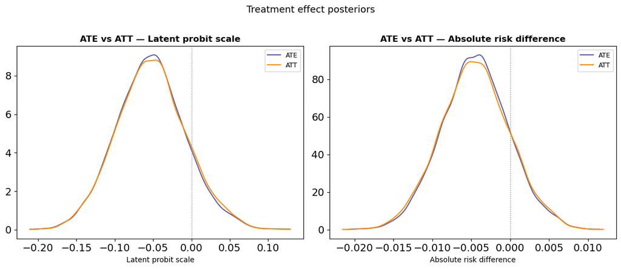

```python
fig, axes = plt.subplots(1, 2, figsize=(12, 5))

for ax, (ate_t, att_t, scale_label) in zip(
    axes,
    [
        (ate_trace,    att_trace,    "Latent probit scale"),
        (ate_rd_trace, att_rd_trace, "Absolute risk difference"),
    ]
):
    az.plot_dist(ate_t, label="ATE", color="#5B5EA6", ax=ax)
    az.plot_dist(att_t, label="ATT", color="darkorange", ax=ax)
    ax.axvline(0, color="gray", lw=1, linestyle=":")
    ax.set_xlabel(scale_label)
    ax.set_title(f"ATE vs ATT — {scale_label}", fontweight="bold")
    ax.legend(fontsize=9)

fig.suptitle("Treatment effect posteriors", fontsize=13, y=1.02)
fig.tight_layout()
plt.savefig(f"{output_folder}bcf_{dx_name}_ate_att.png", dpi=150, bbox_inches="tight")
plt.show()
```

## 9. CATT Waterfall Plot

Sorted individual-level treatment effects on the absolute risk difference scale. Green = treatment reduces exacerbation risk (RD < 0), Red = treatment increases or has no benefit (RD > 0).

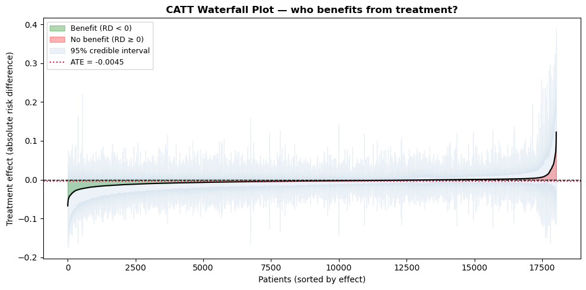

```
Proportion with estimated benefit (RD < 0): 78.8%
```

```python
ird_lo95  = np.percentile(rd_draws, 2.5,  axis=1)
ird_hi95  = np.percentile(rd_draws, 97.5, axis=1)

sort_idx      = np.argsort(ird_mean)
ird_sorted    = ird_mean[sort_idx]
ird_lo_sorted = ird_lo95[sort_idx]
ird_hi_sorted = ird_hi95[sort_idx]
xs = np.arange(len(ird_sorted))

fig, ax = plt.subplots(figsize=(10, 5))
ax.fill_between(xs, 0, ird_sorted, where=(ird_sorted < 0), color="green", alpha=0.3,
                label="Benefit (RD < 0)")
ax.fill_between(xs, 0, ird_sorted, where=(ird_sorted >= 0), color="red", alpha=0.3,
                label="No benefit (RD ≥ 0)")
ax.plot(xs, ird_sorted, color="black", lw=1.5)
ax.fill_between(xs, ird_lo_sorted, ird_hi_sorted, alpha=0.1, color="steelblue",
                label="95% credible interval")
ax.axhline(0, color="black", linestyle="--", lw=1)
ax.axhline(ird_mean.mean(), color="crimson", linestyle=":", lw=1.5,
           label=f"ATE = {ird_mean.mean():.4f}")
ax.set_ylabel("Treatment effect (absolute risk difference)")
ax.set_xlabel("Patients (sorted by effect)")
ax.set_title("CATT Waterfall Plot — who benefits from treatment?", fontweight="bold")
ax.legend(fontsize=9)
fig.tight_layout()
plt.savefig(f"{output_folder}bcf_{dx_name}_waterfall.png", dpi=150, bbox_inches="tight")
plt.show()

pct_benefit = (ird_mean < 0).mean()
print(f"Proportion with estimated benefit (RD < 0): {pct_benefit:.1%}")
```

## 10. Credible-Interval Caterpillar Plot (sorted by τ)

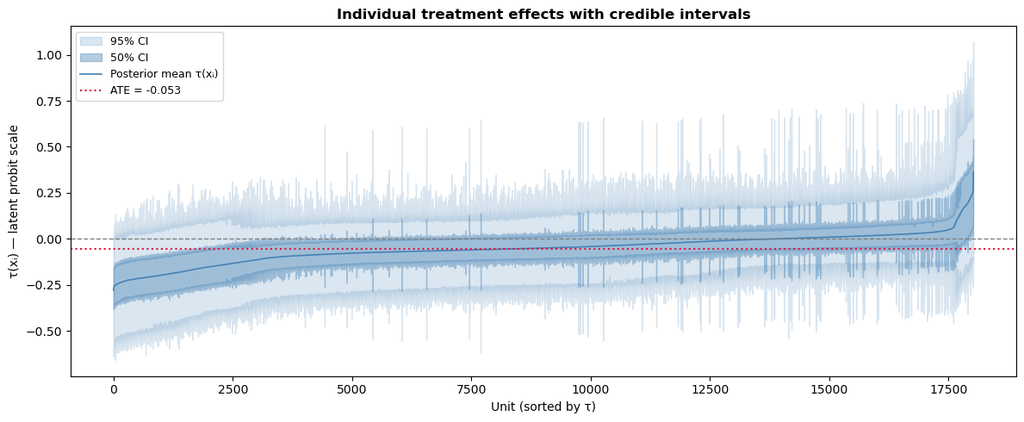

```python
tau_lo50 = np.percentile(tau_draws, 25,  axis=1)
tau_hi50 = np.percentile(tau_draws, 75,  axis=1)

sort_idx_tau = np.argsort(tau_mean)
xs = np.arange(len(tau_mean))

fig, ax = plt.subplots(figsize=(12, 5))
ax.fill_between(xs, tau_lo95[sort_idx_tau], tau_hi95[sort_idx_tau],
                alpha=0.2, color="steelblue", label="95% CI")
ax.fill_between(xs, tau_lo50[sort_idx_tau], tau_hi50[sort_idx_tau],
                alpha=0.4, color="steelblue", label="50% CI")
ax.plot(xs, tau_mean[sort_idx_tau], lw=1.2, color="steelblue",
        label="Posterior mean τ(xᵢ)")
ax.axhline(0, color="gray", lw=1, linestyle="--")
ax.axhline(tau_mean.mean(), color="crimson", lw=1.5, linestyle=":",
           label=f"ATE = {tau_mean.mean():.3f}")
ax.set_xlabel("Unit (sorted by τ)")
ax.set_ylabel("τ(xᵢ) — latent probit scale")
ax.set_title("Individual treatment effects with credible intervals", fontweight="bold")
ax.legend(fontsize=9)
fig.tight_layout()
plt.savefig(f"{output_folder}bcf_{dx_name}_caterpillar.png", dpi=150, bbox_inches="tight")
plt.show()
```

## 11. Treatment Effect vs Prognostic Score

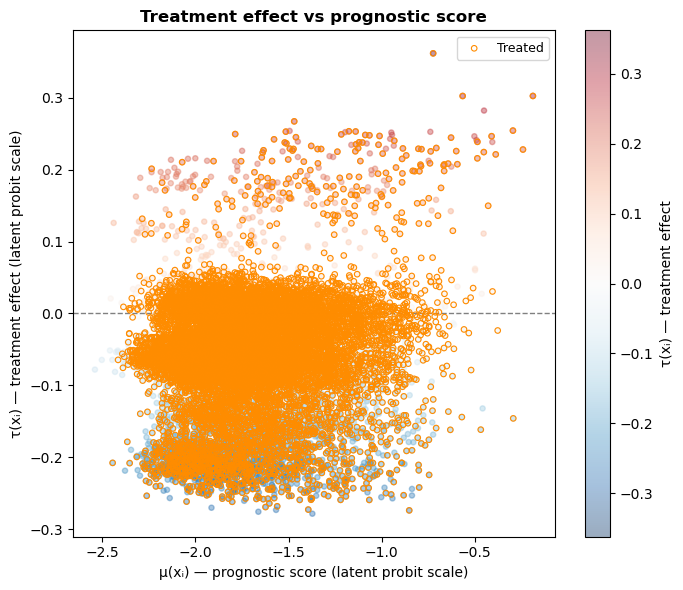

```python
fig, ax = plt.subplots(figsize=(7, 6))
sc = ax.scatter(
    mu_mean, tau_mean,
    c=tau_mean, cmap="RdBu_r",
    alpha=0.4, s=14,
    vmin=-np.abs(tau_mean).max(),
    vmax= np.abs(tau_mean).max()
)
plt.colorbar(sc, ax=ax, label="τ(xᵢ) — treatment effect")
ax.scatter(
    mu_mean[treated_idx], tau_mean[treated_idx],
    s=16, edgecolors="darkorange", facecolors="none", lw=0.8,
    label="Treated", zorder=5
)
ax.axhline(0, color="gray", lw=1, linestyle="--")
ax.set_xlabel("μ(xᵢ) — prognostic score (latent probit scale)")
ax.set_ylabel("τ(xᵢ) — treatment effect (latent probit scale)")
ax.set_title("Treatment effect vs prognostic score", fontweight="bold")
ax.legend(fontsize=9)
fig.tight_layout()
plt.show()
```

## 12. HTE Calibration — Do predicted effect groups show the right observed rates?

[figure not shown]

```python
df_eval = pd.DataFrame({
    "pred_rd" : ird_mean,
    "pred_tau": tau_mean,
    "obs_y"   : y_data.astype(int),
    "T"       : T,
})
df_eval["decile"] = pd.qcut(df_eval["pred_rd"], 10, labels=False, duplicates="drop")

# Observed rate ratio per decile (treated rate / control rate)
def safe_rr(x):
    r_t = x[x["T"] == 1]["obs_y"].mean()
    r_c = x[x["T"] == 0]["obs_y"].mean()
    return r_t / r_c if r_c > 0 else np.nan

decile_rr = df_eval.groupby("decile").apply(safe_rr).reset_index()
decile_rr.columns = ["decile", "rate_ratio"]

fig, ax = plt.subplots(figsize=(10, 5))
sns.barplot(data=decile_rr, x="decile", y="rate_ratio", palette="mako", ax=ax)
ax.axhline(1, color="red", linestyle="--", lw=1.5)
ax.set_xlabel("Predicted treatment effect decile (low → high benefit)")
ax.set_ylabel("Observed rate ratio (treated / control)")
ax.set_title("HTE Calibration — do high-predicted-benefit groups show lower observed rates?",
             fontweight="bold")
fig.tight_layout()
plt.show()
```

## 13. Subgroup CATTs — Forest Plot

For each binary indicator in `feature_list`, we extract the subgroup CATT posterior (mean tau across draws for that subgroup) and plot the 50% and 94% HDI.

```python
X_df = pd.DataFrame(X_base, columns=X_base.columns if hasattr(X_base, 'columns') else [f"x{i}" for i in range(X_base.shape[1])])

def cate_summary(tau_draws, idx):
    """CATE posterior for a subgroup defined by index array idx.
    Returns (mean, lo94, hi94, lo50, hi50, P(tau < 0), n)
    tau_draws: (N, num_mcmc)
    """
    draws = tau_draws[idx].mean(axis=0)   # (num_mcmc,) — CATE posterior
    hdi94 = az.hdi(draws[np.newaxis, :], hdi_prob=0.94)
    hdi50 = az.hdi(draws[np.newaxis, :], hdi_prob=0.50)
    return (
        draws.mean(),
        float(hdi94[:,0][0]), float(hdi94[:,1][0]),
        float(hdi50[:,0][0]), float(hdi50[:,1][0]),
        (draws < 0).mean(),   # P(tau < 0) = P(treatment reduces risk)
        len(idx),
    )

feature_list = [
    "ICS_flag",
    "ICS_LABA_flag",
    "ICS_LABA_LAMA_flag",
    "num_treatments_baseline",
    "num_er_event",
    "hba1c_missing",
    "dyslipidemia_flag",
    "PVD_flag",
    "CAD_flag",
    "t2dm_flag",
    "obstructive_sleep_apnea_flag",
    "hypertension_flag",
    "ckd_flag",
    "bmi_20_25",
    "bmi_above_25",
    "sex_Female",
]

rows = []
for feat in feature_list:
    idx = np.where(X_df[feat].values == 1)[0]
    if len(idx) < 10:
        continue
    mean, lo94, hi94, lo50, hi50, p_neg, n = cate_summary(tau_draws, idx)
    rows.append(dict(feature=feat, mean=mean, lo94=lo94, hi94=hi94,
                     lo50=lo50, hi50=hi50, p_benefit=p_neg, n=n))

df_forest = pd.DataFrame(rows).set_index("feature")
print(df_forest[["mean", "lo94", "hi94", "p_benefit", "n"]].round(3))
```

```
                               mean   lo94   hi94  p_benefit      n
feature
ICS_flag                     -0.070 -0.101 -0.101      0.892    713
ICS_LABA_flag                -0.059 -0.108 -0.108      0.884   3121
ICS_LABA_LAMA_flag           -0.055 -0.106 -0.106      0.842    693
num_treatments_baseline      -0.051 -0.094 -0.094      0.854   4183
num_er_event                 -0.049 -0.091 -0.091      0.856   2338
hba1c_missing                -0.054 -0.095 -0.095      0.879  13112
dyslipidemia_flag            -0.058 -0.104 -0.104      0.893  13480
PVD_flag                     -0.068 -0.113 -0.113      0.899   2466
CAD_flag                     -0.063 -0.028 -0.028      0.879   3135
t2dm_flag                    -0.055 -0.109 -0.109      0.882  12519
obstructive_sleep_apnea_flag -0.058 -0.119 -0.119      0.886   6278
hypertension_flag            -0.057 -0.109 -0.109      0.892  13629
ckd_flag                     -0.167 -0.354 -0.354      0.954   3132
bmi_20_25                     0.116  0.305  0.305      0.505    218
bmi_above_25                 -0.057 -0.132 -0.132      0.886  13315
sex_Female                   -0.052 -0.106 -0.106      0.875  13135
```

```
Subgroup CATTs (latent probit scale):
                               mean   lo94   hi94  p_benefit      n
feature
ICS_flag                     -0.070 -0.210  0.056      0.892    713
ICS_LABA_flag                -0.059 -0.152  0.042      0.884   3121
ICS_LABA_LAMA_flag           -0.055 -0.178  0.074      0.842    693
num_treatments_baseline      -0.051 -0.147  0.041      0.854   4183
num_er_event                 -0.049 -0.139  0.040      0.856   2338
hba1c_missing                -0.054 -0.145  0.031      0.879  13112
dyslipidemia_flag            -0.058 -0.144  0.033      0.893  13480
PVD_flag                     -0.068 -0.175  0.035      0.899   2466
CAD_flag                     -0.063 -0.174  0.041      0.879   3135
t2dm_flag                    -0.055 -0.140  0.036      0.882  12519
obstructive_sleep_apnea_flag -0.058 -0.148  0.038      0.886   6278
hypertension_flag            -0.057 -0.142  0.032      0.892  13629
ckd_flag                     -0.167 -0.356  0.018      0.954   3132
bmi_20_25                     0.116 -0.175  0.659      0.505    218
bmi_above_25                 -0.057 -0.147  0.036      0.886  13315
sex_Female                   -0.052 -0.140  0.032      0.875  13135
```

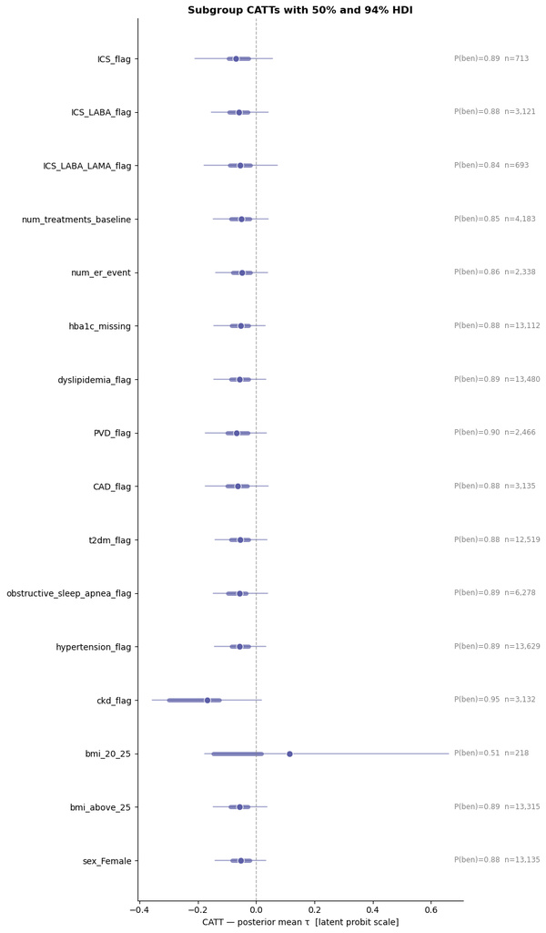

```python
X_tau = X_base.values.astype(float)
X_df = pd.DataFrame(X_tau, columns=X_base.columns.tolist())

def cate_summary(tau_draws, idx):
    """CATE posterior for a subgroup. Returns summary stats."""
    draws = tau_draws[idx].mean(axis=0)       # (num_mcmc,) — CATE posterior for group
    hdi94 = az.hdi(draws, hdi_prob=0.94)      # FIX: 1-D input → returns array([lo, hi])
    hdi50 = az.hdi(draws, hdi_prob=0.50)
    return {
        "mean":      draws.mean(),
        "lo94":      hdi94[0],
        "hi94":      hdi94[1],
        "lo50":      hdi50[0],
        "hi50":      hdi50[1],
        "p_benefit": (draws < 0).mean(),
        "n":         len(idx),
    }

feature_list = [
    "ICS_flag", "ICS_LABA_flag", "ICS_LABA_LAMA_flag",
    "num_treatments_baseline", "num_er_event", "hba1c_missing",
    "dyslipidemia_flag", "PVD_flag", "CAD_flag", "t2dm_flag",
    "obstructive_sleep_apnea_flag", "hypertension_flag", "ckd_flag",
    "bmi_20_25", "bmi_above_25", "sex_Female",
]

rows = []
for feat in feature_list:
    if feat not in X_df.columns:
        continue
    idx = np.where(X_df[feat].values == 1)[0]
    if len(idx) < 10:
        continue
    rows.append({"feature": feat, **cate_summary(tau_draws, idx)})

df_forest = pd.DataFrame(rows).set_index("feature")
print("\nSubgroup CATTs (latent probit scale):")
print(df_forest[["mean", "lo94", "hi94", "p_benefit", "n"]].round(3).to_string())

# Forest plot
fig, ax = plt.subplots(figsize=(9, len(df_forest) * 0.9 + 1))
color = "#5B5EA6"
y_pos = np.arange(len(df_forest))[::-1]

for i, (feat, row) in enumerate(df_forest.iterrows()):
    y = y_pos[i]
    ax.plot([row["lo94"], row["hi94"]], [y, y], lw=1.5, color=color, alpha=0.5,
            solid_capstyle="round")
    ax.plot([row["lo50"], row["hi50"]], [y, y], lw=5, color=color, alpha=0.7,
            solid_capstyle="round")
    ax.scatter(row["mean"], y, s=60, color=color, zorder=5,
               edgecolors="white", linewidths=0.8)
    ax.text(
        df_forest["hi94"].max() + 0.005, y,
        f"  P(ben)={row['p_benefit']:.2f}  n={int(row['n']):,}",
        va="center", fontsize=8.5, color="gray"
    )

ax.axvline(0, color="gray", lw=1, linestyle="--", alpha=0.7)
ax.set_yticks(y_pos)
ax.set_yticklabels(df_forest.index, fontsize=10)
ax.set_xlabel("CATT — posterior mean τ  [latent probit scale]", fontsize=10)
ax.set_title("Subgroup CATTs with 50% and 94% HDI", fontsize=12, fontweight="bold")
ax.spines[["top", "right"]].set_visible(False)
fig.tight_layout()
plt.savefig(f"{output_folder}bcf_{dx_name}_forest_plot.png", dpi=150, bbox_inches="tight")
plt.show()
```

## 14. Decision Tree Proxy — Clinically Interpretable Rules

[output not shown]

[figure not shown]

```python
drop_cols     = ["patid", "outcome", "exposure", "follow_up_time", "weight", "ps_score"]
X_train       = cohort.drop(columns=drop_cols).astype(float).values
feature_names = cohort.drop(columns=drop_cols).columns.tolist()
X_np = X_train.values if isinstance(X_train, pd.DataFrame) else X_train

from sklearn.ensemble import RandomForestRegressor
proxy_rf = RandomForestRegressor(n_estimators=200, max_depth=6,
                                  min_samples_leaf=20, random_state=123)
proxy_rf.fit(X_tau, tau_mean)
fi_df = pd.DataFrame({"feature": feature_names,
                       "importance": proxy_rf.feature_importances_})
print("\nTop 10 features driving HTE:")
print(fi_df.head(10).reset_index(drop=True).to_string(index=False))

explainer   = shap.TreeExplainer(proxy_tree)
shap_values = explainer.shap_values(X_np)
shap.summary_plot(shap_values, X_np, feature_names=feature_names, max_display=15,)
```